# Project 2: Data Mining, Classification, Prediction

SDS322E

# Mining, Classification, Prediction

## Sneha Venkatesan (sv23377)

### Introduction

```r
library(tidyverse)

# Store dataset in a variable called 'college'
college <- read_csv("/stor/home/sv23377/project2/College.csv")

# Number of instances of the binary variable
college %>% group_by(Private) %>% summarize(count = n())
```

```
## # A tibble: 2 x 2
##   Private count
##   <chr>   <int>
## 1 No        212
## 2 Yes       565
```

### Cluster Analysis

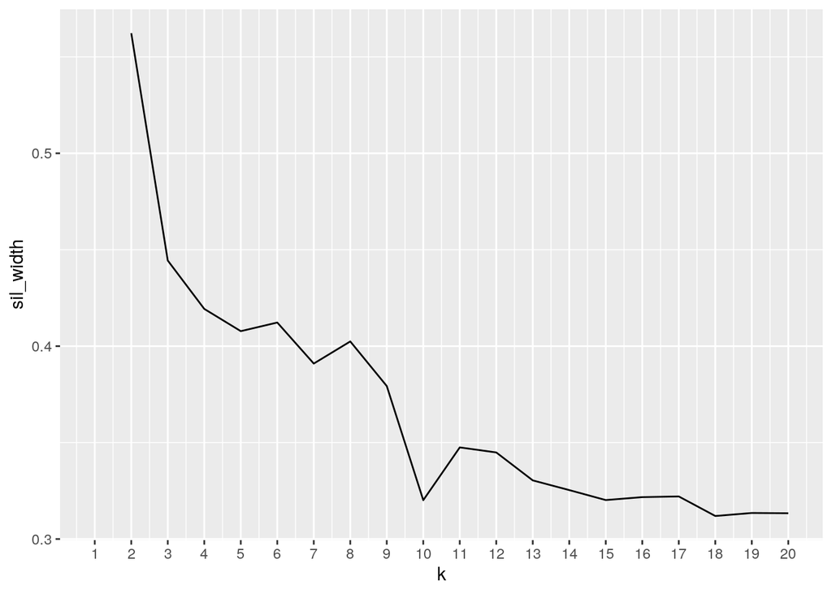

```r
library(cluster)
library(ggplot2)
require(GGally)
clust_dat <- college %>% dplyr::select(5, 8, 10, 13, 16)
sil_width <- vector()  #empty vector to hold mean sil width
for (i in 2:20) {
    kms <- kmeans(clust_dat, centers = i)  #compute k-means solution for each k
    sil <- silhouette(kms$cluster, dist(clust_dat))  #get sil widths
    sil_width[i] <- mean(sil[, 3])  #take averages (higher is better)
}
ggplot() + geom_line(aes(x = 1:20, y = sil_width)) + scale_x_continuous(name = "k",
    breaks = 1:20)
```

```r
college_pam <- clust_dat %>% pam(k = 2)  #PAM function
pamclust <- clust_dat %>% mutate(cluster = as.factor(college_pam$clustering))  #Save cluster assignments
pamclust %>% group_by(cluster) %>% summarize_if(is.numeric, mean,
    na.rm = T)  #Mean variables in each cluster
```

```
## # A tibble: 2 x 6
##   cluster Enroll F.Undergrad Outstate Personal S.F.Ratio
##   <fct>    <dbl>       <dbl>    <dbl>    <dbl>     <dbl>
## 1 1         426.       1746.   11233.    1236.      13.3
## 2 2        2168.      11354.    7335.    1751.      17.1
```

```r
college %>% slice(college_pam$id.med)  #Most representative of cluster
```

```
## # A tibble: 2 x 19
##   X1    Private  Apps Accept Enroll Top10perc Top25perc F.Undergrad P.Undergrad
##   <chr> <chr>   <dbl>  <dbl>  <dbl>     <dbl>     <dbl>       <dbl>       <dbl>
## 1 Sain… Yes      1046    824    284        21        45        1223         451
## 2 Appa… No       7313   4664   1910        20        63        9940        1035
## # … with 10 more variables: Outstate <dbl>, Room.Board <dbl>, Books <dbl>,
## #   Personal <dbl>, PhD <dbl>, Terminal <dbl>, S.F.Ratio <dbl>,
## #   perc.alumni <dbl>, Expend <dbl>, Grad.Rate <dbl>
```

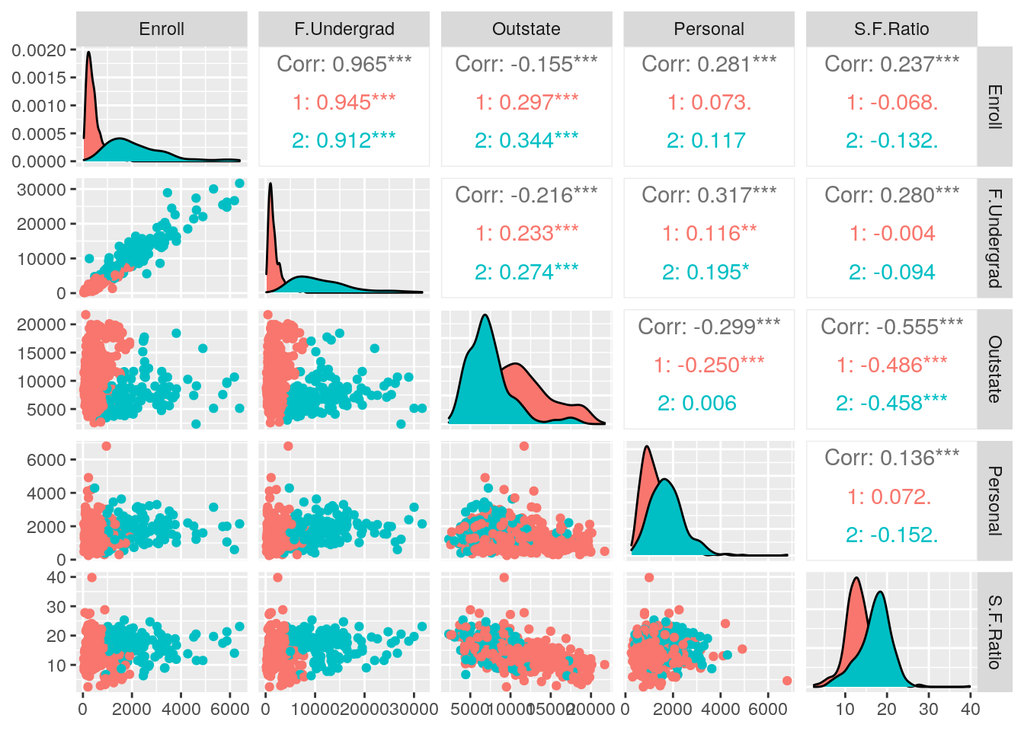

```r
# Pairwise combination of all variables
college %>% mutate(cluster = as.factor(college_pam$clustering)) %>%
    ggpairs(columns = c(5, 8, 10, 13, 16), aes(color = cluster))
```

I chose the following variables to explore:Enroll, F.Undergrad, Outstate, Personal, S.F.Ratio. I chose these variables because I predict these variables would be correlated with whether the school is private or public. Plotting the largest average silhouette width showed that a cluster solution is best with 2 clusters. The cluster assignments have been saved to pamclust. The summarized means for each variable in each cluster were calculated. Saint Francis College and Appalachian State University are the most representative of each cluster. Enroll and F.Undergrad had the least overlap with the two clusters. Personal and S.F. Ratio had the most cluster overlap.

### Dimensionality Reduction with PCA

```r
college1 <- college %>% select(1, 2, 5, 8, 10, 13, 16)  #Select variables of interest
college_nums <- college1 %>% select_if(is.numeric) %>% scale  #Scale data
rownames(college_nums) <- college1$Name
college_pca <- princomp(college_nums)  #Perform PCA
names(college_pca)
```

```
## [1] "sdev"     "loadings" "center"   "scale"    "n.obs"    "scores"   "call"
```

```r
summary(college_pca, loadings = T)  #Summary of PCA
```

```
## Importance of components:
##                           Comp.1    Comp.2    Comp.3     Comp.4      Comp.5
## Standard deviation     1.5607813 1.1292549 0.9201971 0.63446969 0.181647302
## Proportion of Variance 0.4878355 0.2553720 0.1695708 0.08061411 0.006607653
## Cumulative Proportion  0.4878355 0.7432075 0.9127782 0.99339235 1.000000000
##
## Loadings:
##             Comp.1 Comp.2 Comp.3 Comp.4 Comp.5
## Enroll       0.546  0.426  0.166         0.698
## F.Undergrad  0.567  0.375  0.144        -0.714
## Outstate    -0.357  0.621        -0.696
## Personal     0.341        -0.895 -0.279
## S.F.Ratio    0.370 -0.536  0.388 -0.652
```

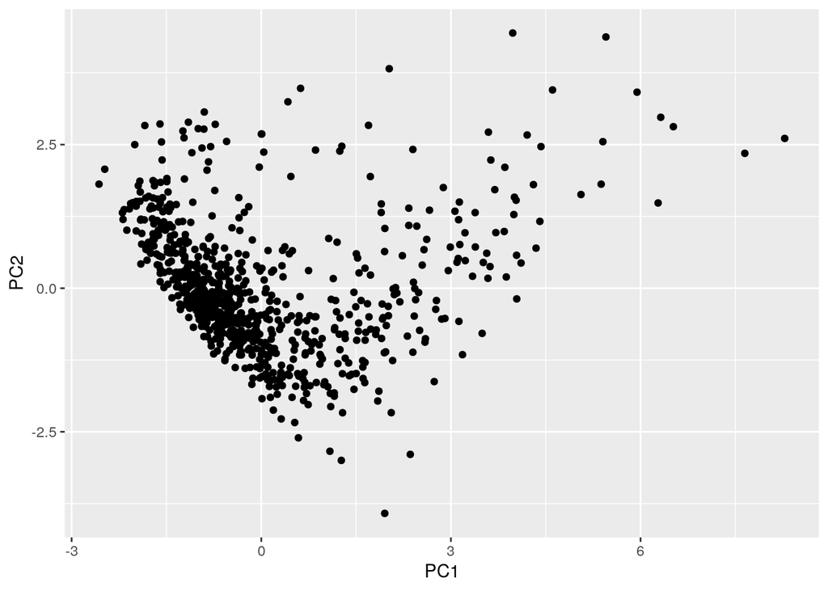

```r
collegef <- data.frame(Name = college1$X1, PC1 = college_pca$scores[,
    1], PC2 = college_pca$scores[, 2])
ggplot(collegef, aes(PC1, PC2)) + geom_point()  #Plot of PC Scores for each datapoint
```

Selecting the variables of interest (Enroll, F.Undergrad, Outstate, Personal, S.F.Ratio) and normalizing the data, a PCA was performed. High scores on Principal Component 1 indicate a high number of students enrolled, a high number of full time undergraduates, low on out of state tuition, high on personal expenses, and high on student-to-faculty ratio. Low scores on Principal Component 1 indicate a low number of students enrolled, a low number of full time undergraduates, high on out of state tuition, low on personal expenses, and low on student-to-faculty ratio. High scores on Principal Component 2 indicate a high number of students enrolled, a high number of full time undergraduates, high on out of state tuition, and low on student-to-faculty ratio. Low scores on Principal Component 2 indicate a low number of students enrolled, a low number of full time undergraduates, low on out of state tuition, and high on student-to-faculty ratio. High scores on Principal Component 3 indicate a high number of students enrolled, a high number of full time undergraduates, low on out of personal expenses, and high on student-to-faculty ratio. Low scores on Principal Component 3 indicate a low number of students enrolled, a low number of full time undergraduates, high on out of personal expenses, and low on student-to-faculty ratio..Principal Component 1 accounts for 49% of variance. Principal Component 2 accounts for 26% of variance. Principal Component 3 accounts for 17% of the variance.

### Linear Classifier

```r
college2 <- college %>% mutate(Private = ifelse(Private == "Yes",
    1, 0)) %>% mutate(Private = as.logical(Private)) %>% mutate_at(c(3:18),
    as.integer)
logistic_fit <- glm(Private == "True" ~ Apps + Accept + Enroll +
    Top10perc + F.Undergrad + Outstate + Personal + perc.alumni +
    Expend, data = college2, family = "binomial")

prob_reg <- predict(logistic_fit, type = "response")
class_diag(prob_reg, college2$Private, positive = 1)
```

```
##            acc sens spec ppv  f1  ba    auc
## Metrics 0.2728    0    1 NaN NaN 0.5 0.4111
```

```r
table(truth = college2$Private, predictions = prob_reg > 0.5)
```

```
##        predictions
## truth   FALSE
##   FALSE   212
##   TRUE    565
```

```r
set.seed(322)
k = 10

data <- sample_frac(college2)  #randomly order rows
folds <- rep(1:k, length.out = nrow(data))  #create folds

diags <- NULL

i = 1
for (i in 1:k) {
    # create training and test sets
    train <- data[folds != i, ]
    test <- data[folds == i, ]
    truth <- test$Private

    # train model
    fit <- glm(Private ~ Apps + Accept + Enroll + Top10perc +
        F.Undergrad + Outstate + Personal + perc.alumni + Expend,
        data = test, family = "binomial")

    # test model
    probs <- predict(fit, newdata = test, type = "response")

    # get performance metrics for each fold
    diags <- rbind(diags, class_diag(probs, truth, 1))
}

# average performance metrics across all folds
summarize_all(diags, mean)
```

```
##       acc    sens    spec     ppv      f1      ba     auc
## 1 0.98461 0.99052 0.97186 0.98695 0.98872 0.98119 0.99419
```

The logistic regression had a low AUC, which indicates that the model is not performing well. There is not a lot of separation between the two conditions. The model does better in cross validation since the auc increases to 0.99, so there is not much overfitting.

### Non-Parametric Classifier

```r
library(caret)
knn_fit <- knn3(Private == "True" ~ Apps + Accept + Enroll +
    Top10perc + F.Undergrad + Outstate + Personal + perc.alumni +
    Expend, data = college2)

prob_knn <- predict(knn_fit, college2)
class_diag(prob_knn[, 1], college2$Private, positive = 1)
```

```
##            acc sens spec    ppv    f1  ba auc
## Metrics 0.7272    1    0 0.7272 0.842 0.5 0.5
```

```r
# confusion matrix
y <- college2$Private
yhat <- prob_knn
table(actual = y, predicted = yhat)
```

```
##        predicted
## actual    1
##   FALSE 212
##   TRUE  565
```

```r
set.seed(322)
k = 10

data <- sample_frac(college2)  #randomly order rows
folds <- rep(1:k, length.out = nrow(data))  #create folds

diags <- NULL

i = 1
for (i in 1:k) {
    # create training and test sets
    train <- data[folds != i, ]
    test <- data[folds == i, ]
    truth <- test$Private

    # train model
    fit <- glm(Private ~ Apps + Accept + Enroll + Top10perc +
        F.Undergrad + Outstate + Personal + perc.alumni + Expend,
        data = train, family = "binomial")

    # test model
    probs <- predict(fit, newdata = test, type = "response")

    # get performance metrics for each fold
    diags <- rbind(diags, class_diag(probs, truth, positive = 1))
}

# average performance metrics across all folds
summarize_all(diags, mean)
```

```
##       acc    sens    spec     ppv      f1      ba     auc
## 1 0.93311 0.96137 0.86708 0.94775 0.95382 0.91423 0.97658
```

### Regression/Numeric Prediction

```r
college3 <- college2 %>% select(-1, -2)
fit <- lm(Apps ~ ., data = college3)  #predict number of applicants from all other variables
yhat <- predict(fit)  #predicted applicants
mean((college$Apps - yhat)^2)  #mean squared error (MSE)
```

```
## [1] 1077220
```

```r
set.seed(1234)
k = 5  #choose number of folds
data <- college3[sample(nrow(college3)), ]  #randomly order rows
folds <- cut(seq(1:nrow(college3)), breaks = k, labels = F)  #create folds
diags <- NULL
for (i in 1:k) {
    train <- data[folds != i, ]
    test <- data[folds == i, ]
    ## Fit linear regression model to training set
    fit <- lm(Apps ~ ., data = train)
    ## Get predictions/y-hats on test set (fold i)
    yhat <- predict(fit, newdata = test)
    ## Compute prediction error (MSE) for fold i
    diags <- mean((test$Apps - yhat)^2)
}
mean(diags)  # MSE
```

```
## [1] 916778.4
```

The measure of prediction is large when a linear regression model is fitted to the dataset. The average MSE across your k testing folds is lower in k-fold cross validation, so there is not much overfitting.

### Python

```r
library(reticulate)
use_python("/usr/bin/python3", required = F)
college_cost <- college %>% mutate(total_cost = (Room.Board +
    Books + Personal))
```

```python
college_cost = r.college_cost

college_cost['tot_stu_cost'] = college_cost['total_cost']*college_cost['Enroll']
```

```r
head(py$college_cost)
```

```
##                             X1 Private Apps Accept Enroll Top10perc Top25perc
## 1 Abilene Christian University     Yes 1660   1232    721        23        52
## 2           Adelphi University     Yes 2186   1924    512        16        29
## 3               Adrian College     Yes 1428   1097    336        22        50
## 4          Agnes Scott College     Yes  417    349    137        60        89
##   F.Undergrad P.Undergrad Outstate Room.Board Books Personal PhD Terminal
## 1        2885         537     7440       3300   450     2200  70       78
## 2        2683        1227    12280       6450   750     1500  29       30
## 3        1036          99    11250       3750   400     1165  53       66
## 4         510          63    12960       5450   450      875  92       97
##   S.F.Ratio perc.alumni Expend Grad.Rate total_cost tot_stu_cost
## 1      18.1          12   7041        60       5950      4289950
## 2      12.2          16  10527        56       8700      4454400
## 3      12.9          30   8735        54       5315      1785840
## 4       7.7          37  19016        59       6775       928175
##  [ reached 'max' / getOption("max.print") -- omitted 2 rows ]
```

The total cost for an average student was calculated for each student in R. Then in python, the total cost calculated was multiplied with the total number of students enrolled to attain the total amount spent across all students. The results of the calculations are seen in R.